# Modelo de Regresión

## Introducción

El modelo de regresión lineal es un modelo matemático que tiene como objetivo examinar la relación lineal que existe entre una variable dependiente (Y) y una o varias variables independientes (X), lo anterior, siempre y cuando exista un marco teórico que respalda dicha dependencia o relación instrinsica de la variable dependiente (Y) con las variables explicativa (X). Se destaca además que, a pesar de ser un modelo matemático el mismo no es deterministico, es decir, la relación que existe entre la variables X y Y no es exacta debido al componente de aleatoriedad, en otras palabras, el valor de Y pueden (en la mayoria de los casos) no coincidir con el valor que el modelo arroja para su correspondiente valor o valores de X. Esta relación lineal se plantea de la siguiente forma:

$$ Y= \beta_{0} + \beta_{1}\mathit{x_{1}} + \beta_{2}\mathit{x_{2}} ... + \beta_{p}\mathit{x_{p}} + \epsilon $$

Donde $\beta_{0}$ es el intercepto, el cual no en todas las ocasiones es interpretable, $\beta_{i}$ es la influencia o el peso en el cual aporta la variable $\mathit{x_{i}}$ a la explicación del comportamiento de la variable Y, y $\epsilon$ es una variable aleatoria que representa el error de estimación entre el modelo y la realidad.

[figure not shown]

Para ampliar la anterior información, se pueden visitar las siguientes fuentes de información

1. [Regresion lineal simple](https://fide.dev/2019/10/03/regresion-lineal-simple/)
2. [Estadística y machine learning con R](https://bookdown.org/content/2274/modelo-lineal-general.html)
3. [Que es el modelo de regresion](https://www.questionpro.com/blog/es/analisis-de-regresion/)

## Historia

El primer método de regresión lineal documentado fue el método de los mínimos cuadrados en el año 1805 publicada por Leggendre, en un apendice de 9 páginas, Gauss luego publica un trabajo en donde se desarrolla de manera más profunda el método de los mínimos cuadrados, donde incluía una versión del teorema de Gauss-Markov el cual muestra que de todas las combinaciones lineales medidas para estimar una incognita, el método de los mínimos cuadrados tiene una mínima varianza, independientemente de la distribución de los errores.

El término se usa por primera vez por Francis Galton en 1889, en un trabajo que se centraba en la descripción de los rasgos físicos de los hijos teniendo como variable explicativa los rasgos físicos de sus padres. En su estudio, se comparaba la altura de los padres e hijos donde se concluye que los padres muy alto tendían a tener hijos con alturas superiores a la media, sin embargo, estos últimos tendían a reducir su diferencia con respecto a la media y se acercaban de esta manera al promedio, de igual manera mostró que sucedía lo mismo con padres que eran muy bajos.

Esta información fue extraida de los siguientes enlaces de internet

1. [Revista Estadística número 1](https://issuu.com/crismarcontreras6/docs/revista_estadistica)
2. [Wikipedia: Regresión lineal](https://es.wikipedia.org/wiki/Regresi%C3%B3n_lineal#:~:text=La%20primera%20forma%20de%20regresi%C3%B3n,del%20teorema%20de%20Gauss%2DM%C3%A1rkov.)
3. Metodo de minimos cuadrados: Una revision historica

## Desarrollo del algoritmo

### Regresion lineal Simple

El modelo de regresión lineal simple se basa en la construcción de un modelo $ Y= \beta_{0} + \beta_{1}\mathit{x} + \epsilon $, y tiene en cuenta para su construcción una sola variable independiente o explicativa $X$ la cual toma valores tales que $X \in \mathbb R$, por otro lado, este modelo tiene en cuenta la variable $Y$ la cual es dependiente o es explicada en gran parte por los valores que toma la varible $x$.

Como se explicó anteriormente, este modelo tiene otros componentes; los $\beta_{0}$ y $\beta_{1}$, el intercepto y la pendiente correspondientemente, los cuales corresponden a los parámetros de la regresión lineal y son constantes, y un $\epsilon$ que corresponde al error que comete el modelo al hacer sus correspondientes estimaciones.

Para poder encontrar el modelo que mejor se ajusta a los datos, se debe minimizar la suma de los errores o residuos del modelo definidos como $\epsilon = Y_{i} - \hat{Y_{i}}$, donde $\hat{Y_{i}}$ corresponde a la predicción de los valores por el modelo que tiene como parametros los coeficientes $\hat{\beta_{0}}$ y $\hat{\beta_{1}}$ que minimizan la suma de los errores. De este modo entre más se logre minimizar o reducir el error $\epsilon$ pasará que $\hat{Y}\approx Y $.

Mediante el método de los mínimos cuadrados es posible conseguir los coeficientes que minimizan la suma de los errores al cuadrado.

$$RSS = \sum_{i=1}^{n} \epsilon^{2} $$

Para ello, se deben encontrar las derivadas parciales respecto a los coeficientes $\hat{\beta_{0}}$ y $\hat{\beta_{1}}$ e igualar los mismos a 0 para encontrar sus puntos críticos, en este caso mínimos. Los resultados de los valores mínimos se muestran a continuación

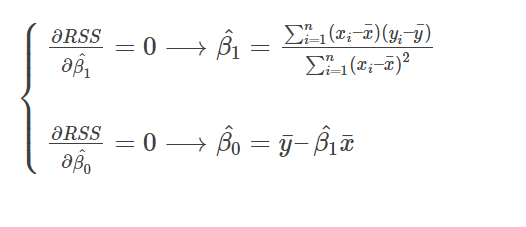

Fuente:

[Regresión Lineal en python](https://machinelearningparatodos.com/regresion-lineal-en-python/)

## Ejemplo regresión lineal: Area cosechada por cultivo vs Rendimiento

```
215
                            OLS Regression Results
==============================================================================
Dep. Variable:                      y   R-squared:                       0.984
Model:                            OLS   Adj. R-squared:                  0.984
Method:                 Least Squares   F-statistic:                 1.323e+04
Date:                Sun, 14 Mar 2021   Prob (F-statistic):          1.04e-193
Time:                        13:43:46   Log-Likelihood:                -1156.6
No. Observations:                 215   AIC:                             2317.
Df Residuals:                     213   BIC:                             2324.
Df Model:                           1
Covariance Type:            nonrobust
==============================================================================
                 coef    std err          t      P>|t|      [0.025      0.975]
------------------------------------------------------------------------------
Intercept     -5.0621      1.891     -2.677      0.008      -8.789      -1.335
x[0]          -5.0621      1.891     -2.677      0.008      -8.789      -1.335
x[1]          18.2167      0.158    115.037      0.000      17.905      18.529
==============================================================================
Omnibus:                       19.000   Durbin-Watson:                   2.398
Prob(Omnibus):                  0.000   Jarque-Bera (JB):               69.896
Skew:                          -0.046   Prob(JB):                     6.64e-16
Kurtosis:                       5.792   Cond. No.                     4.45e+18
==============================================================================

Notes:
[1] Standard Errors assume that the covariance matrix of the errors is correctly specified.
[2] The smallest eigenvalue is 6.2e-33. This might indicate that there are
strong multicollinearity problems or that the design matrix is singular.
```

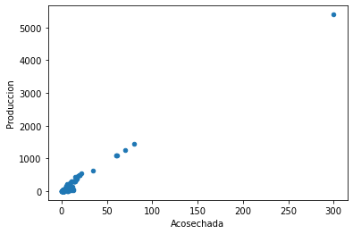

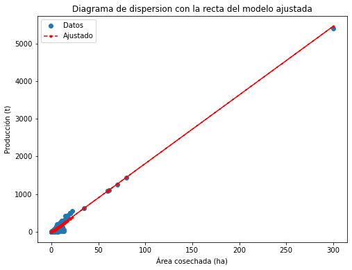

```python
import pandas as pd
import statsmodels.api as sm
import statsmodels.formula.api as smf
import matplotlib.pyplot as plt
import numpy as np

##Lectura de los datos desde excel csv
ruta_archivo =r"C:\Users\afinf\OneDrive\Escritorio\Documentos Andres Infante\Estudios\UNAL\Posgrado\Asignaturas\Semestre 2\Topicos Avanzados de Estadistica\Tareas\Tarea #2 - Regresión Lineal-Jupyter\Acelgas1.csv"
datos_cultivos =pd.read_csv(ruta_archivo,index_col=0, sep=';')

##Imprimir los primeros datos y ver si corresponde a tabla
datos_cultivos.head(5)

#Revisar nombre de las columnas y cambiar
datos_cultivos.columns
print(len(datos_cultivos))

#Primera grafica mediante diagrama de dispersion
datos_cultivos.plot(kind='scatter', x='Acosechada', y='Produccion');

#Crear modelo de regresion

x = datos_cultivos['Acosechada']
x = sm.add_constant(x)
y = datos_cultivos['Produccion']

Modelo1 = sm.OLS(y,x).fit()
predictions = Modelo1.predict(x)

#resumen del modelo ajustado

Modelo1.summary()

#Ajustar el modelo mediante formulas
Modelo2 = smf.ols('y~x', data=datos_cultivos).fit()

#Obtener resumen del modelo ajustado
print(Modelo2.summary())


#Agregar la recta de la regresión estimada

fig, ax = plt.subplots(figsize=(8,6))
ax.plot(datos_cultivos['Acosechada'], datos_cultivos['Produccion'], 'o', label = 'Datos')
ax.plot(datos_cultivos['Acosechada'], Modelo2.fittedvalues, 'r--.', label= 'Ajustado')
legend = ax.legend(loc="best")
plt.xlabel('Área cosechada (ha)')
plt.ylabel('Producción (t)')
plt.title('Diagrama de dispersion con la recta del modelo ajustada')
```

Para ampliar más información acerca del código y de dónde se extrajeron los datos se puede consultar los siguientes enlaces

1. [Datos: AREA COSECHADA POR CULTIVO Vs RENDIMIENTO](https://www.datos.gov.co/Agricultura-y-Desarrollo-Rural/AREA-COSECHADA-POR-CULTIVO-Vs-RENDIMIENTO/qe4x-bk9t)
2. [Regresion lineal en python](https://yuasaavedraco.github.io/Docs/Regresi%C3%B3n_Lineal_Simple_con_Python.html)
3. [Video youtube, Regresion lineal con python](https://www.youtube.com/watch?v=ZhdJ1zGtxFw&t=4s)

## Conclusión

Se concluye que el modelo de regresión lineal ha sido una herramienta de gran utilidad en el análisis de diferentes fenómenos cuantitativos que se dan en las diferentes áreas del conocimiento desde las ciencias sociales, la económia, hasta las ciencias exactas como la física, la quimica entre otros. Lo anterior se da gracias que mediante este es posible modelar los fenomenos lineales a partir de variables explicativas, cuantificar la relación que tienen las diferentes variables, realizar predicciones o pronósticos donde se estima un valor futuro con base en valores hipotéticos y la simulación de los efectos que tendría la variable respuesta Y ante cambios de la variable X.